# Course Project 1

Hellen

10/27/2019

## Set a directory

```r
setwd("/Users/Apple/data/cousera5week2project")
```

## Question1

Code for reading in the dataset and/or processing the data

```r
data_activity<-read.csv("activity.csv")
```

## Question2

```r
data_activity_rm<-subset(data_activity,data_activity$steps!="NA")
```

2.Calculate the total number of steps taken per day

```r
data_activity_sum<-tapply(data_activity_rm$steps,data_activity_rm$date,sum)
```

3.Reshape the dataset

```r
data_activity_sum<-as.data.frame(data_activity_sum)
```

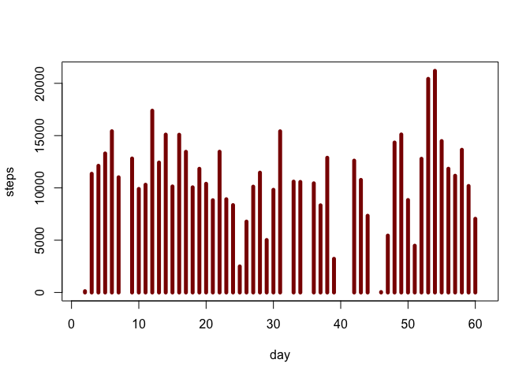

```r
plot(data_activity_sum,type="h",xlab="day",ylab="steps",col="dark red",lwd=5)
```

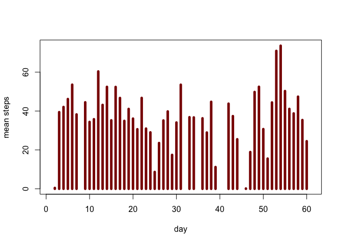

```r
data_activity_mean<-tapply(data_activity_rm$steps,data_activity_rm$date,mean)
plot(data_activity_mean,type = "h",xlab="day",ylab="mean steps",col="dark red",lwd=5)
```

##Question4 Time series plot of the average number of steps taken

```r
data_activity_mean1<-as.data.frame(data_activity_mean)
library(dplyr)
```

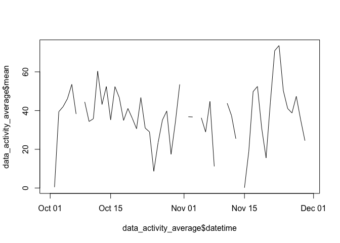

```r
data_activity_mean1$y<-rownames(data_activity_mean1)
data_activity_average<-merge(data_activity_mean1,data_activity,by.x="y",by.y="date")
colnames(data_activity_average)<-c("datetime","mean","step","interval")
data_activity_average$datetime<-as.Date(data_activity_average$datetime)
plot(data_activity_average$datetime,data_activity_average$mean,type = "l")
```

```r
data_activity_max<-tapply(data_activity$steps,data_activity$date,max)
data_activity_max<-as.data.frame(data_activity_max)
data_activity_max$datetime<-rownames(data_activity_max)
```

## Question6

```r
sum(!complete.cases(data_activity))
```

```
## [1] 2304
```

2.Devise a strategy for filling in all of the missing values in the dataset. The strategy does not need to be sophisticated.

```r
library(reshape2)
install.packages("Hmisc")
```

[output not shown]

[output not shown]

```r
library(Hmisc)
data_activity_rs<-dcast(data_activity,interval~date,value.var="steps")
a<-colnames(data_activity_rs)[2:61]
for (i in a) {impute(data_activity_rs$i,mean)}
```

## Question7

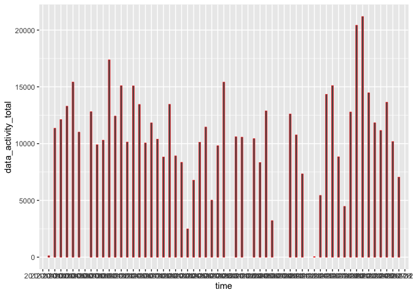

```r
library(reshape2)
data_activity1<-melt(data_activity_rs,id="interval",variable.name = "date",value.name ="steps")
data_activity_total<-tapply(data_activity1$steps, data_activity$date, sum)
data_activity_total<-as.data.frame(data_activity_total)
data_activity_total$time<-rownames(data_activity_total)
ggplot(data = data_activity_total,aes(time,data_activity_total))+geom_bar(stat = "identity",width = 0.3,colour="red",size=0.25)
```

## Question8

Panel plot comparing the average number of steps taken per 5-minute interval across weekdays and weekends 1.Create a new factor variable in the dataset with two levels weekday and weekend indicating whether a given date is a weekday or weekend day. 2.Reshape the original data,creat a new one that can compare the same interval in different day

```r
data_activity_inter<-dcast(data_activity,date~interval,value.var="steps")
```

3.Add a new col which indicate whether the date is a weekend

```r
data_activity_inter$week<-weekdays(as.Date(data_activity_inter$date))
week<-data_activity_inter$week=="Saturday"|data_activity_inter$week=="Sunday"
week[which(week=="FALSE")]<-"weekdays"
week[which(week!="weekdays")]<-"weekends"
data_activity_inter$week<-week
```

4.Calulate the average of per 5-minute interval across weekdays and weekends #remove the “NA” values

```r
data_activity_week<-data_activity_inter[complete.cases(data_activity_inter),]
```

5.Calulate the average of per 5-minute interval

```r
data_activity_week<-aggregate(data_activity_week[,2:289],list(data_activity_week[,290]),mean)
```

6.make a panel plot comparing the average number of steps taken per 5-minute interval across weekdays and weekends use melt function and dcast function to reshape the data

```r
colnames(data_activity_week)[1]<-"week"
panel_data<-melt(data_activity_week,id<-"week",variable.name = "interval",value.name = "mean_steps")
panel_data1<-dcast(panel_data,interval~week,value.var="mean_steps")
```

make a plot

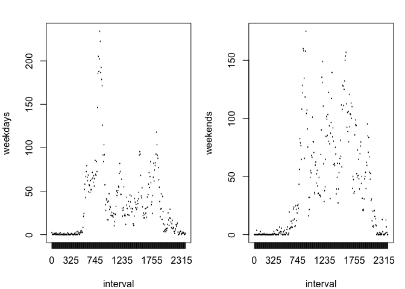

```r
par(mfrow=c(1,2),mar=c(4,4,2,1))
plot(x=panel_data1$interval,y=panel_data1$weekdays,xlab="interval",ylab="weekdays")
plot(x=panel_data1$interval,y=panel_data1$weekends,xlab="interval",ylab="weekends")
```